# Model Performance And Fit - 1

One should look for what is and not what he thinks should be. (Albert Einstein)

# Model Performance and Fit: Topic introduction

In this part of the course, we will cover the following concepts:

- Implement a custom neural network to demonstrate model fit with different learning rates, epochs and batch sizes
- Understand loss functions and math behind gradient descent
- Assess and discuss methods to improve the fit of a neural network

# Warm up: Quick, Draw!

[figure not shown]

- Quick, Draw! is an online game that uses neural network intelligence to guess what the drawings represent
- Visit the website to play [Quick, Draw!](https://quickdraw.withgoogle.com/)
- After completing, share how many of your doodles were correctly recognized

# Module completion checklist

| Objective | Complete |
| --- | --- |
| Summarize the role that batch size and epochs play in neural network training |  |
| Implement a custom neural network to demonstrate model fit with different learning rates |  |

# Epoch

- When the entire dataset is passed through a neural network, we consider one epoch of the training complete
  - Since the dataset can be too big to feed into the neural network, we divide it into **several smaller batches**
  - The number of batches needed to complete the epoch equals to the number of **iterations** per epoch the algorithm needs to make

# Batch

- Batch size is a parameter we define while fitting the model
- It refers to the **number of observations our model takes at a time to make predictions** and update the weights in the following manner:
  - the algorithm **iterates** over one or more observations making predictions at the end of each batch
  - predictions are then compared and an error is calculated
  - this error term is then used to adjust the weights

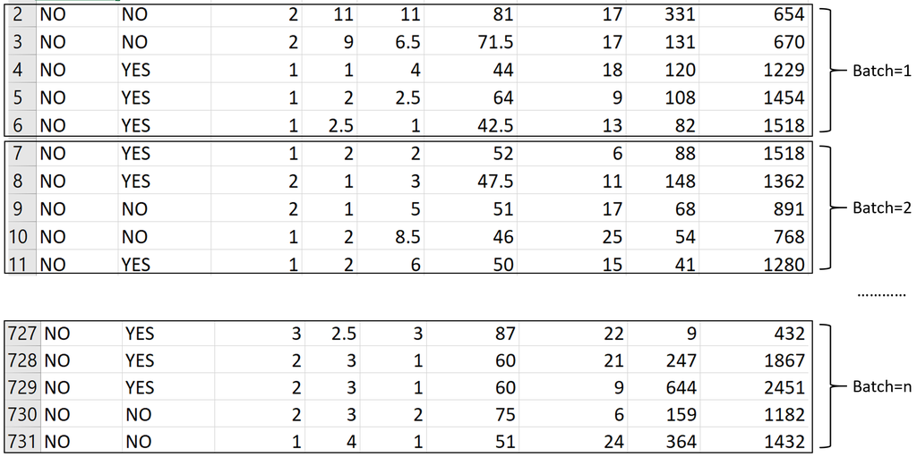

# Batch order

- **Batches are selected randomly during each epoch**, unless we specify otherwise
  - Most problems are agnostic to the order of observations in batches and the order of batches
  - Some models, like time series problems, do need to have observations appear in order and need batch options set accordingly

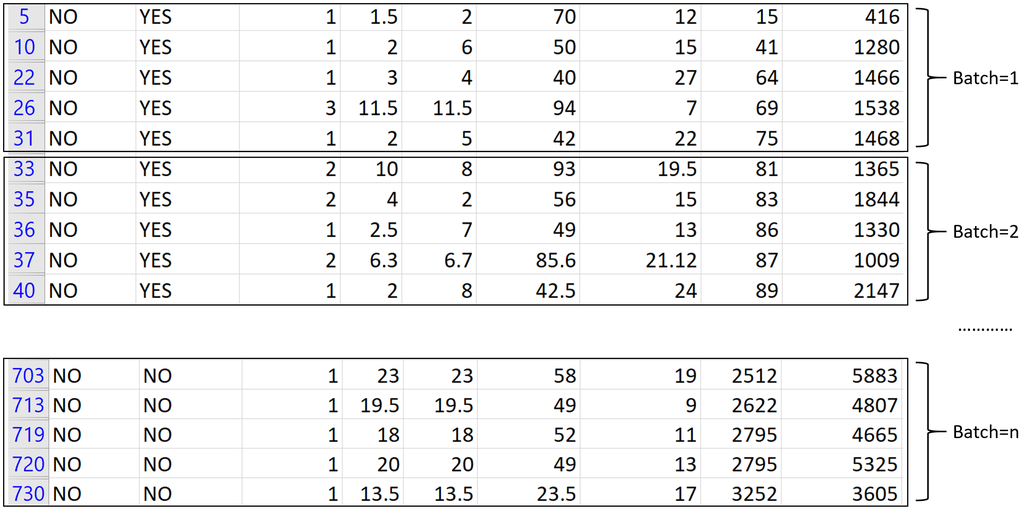

# Batch size implications

- Batch size plays a big role in the time it takes to train the model and how well the model is doing
- With a small batch size, expect:
  - a longer train time
  - higher accuracy (which may lead to model overfitting)
  - it easily fits in computer memory
- With a medium batch size, expect:
  - a balance between training time and accuracy
  - better generalization to new data
  - it fits in memory
- With a large batch size, expect:
  - a faster training time, especially if training is done in parallel
  - it may generalize to new data poorly
  - it could be too big to fit into memory

# Batch size implications (cont’d)

- A single batch can:
  - consist of a single observation (`batch_size = 1`), known as **stochastic gradient descent**
  - be as large as your dataset (`batch_size = num_observations`), known as **batch gradient descent**
  - be any value between `1` and the total `num_observations`, known as **mini-batch gradient descent**
- The default value for a batch size in TensorFlow and many other neural network frameworks is `32`

# Batch size calculations

- `num_observations / batch_size` will provide the total number of resulting batches
- If the `batch_size` doesn’t evenly divide into `num_observations`, the last batch will be smaller than the rest
  - If the model is sensitive to batches having the same outer dimension, set the `drop_remainder` argument to `True` to drop the smaller batch

# Example: batch size, iterations, and epochs math

- Let’s say you have a dataset with `1000` observations and you choose to set the batch size to `50` and the epochs to `200`:
  - `num_observations = 1000`
  - `batch_size = 50`
  - `epochs = 200`
- This means that the entire dataset will be split into `20` batches, each with `50` observations:
  - `num_batches = num_observations / batch_size = 20`
- This also means that `1` epoch will involve `20` batches or `20` updates in the model
  - `iterations = num_batches = 20`
- With `200` epochs, the model passes through the entire dataset `200` times, which means
  - `total_iterations = epochs*iterations = 4000`

# Module completion checklist

| Objective | Complete |
| --- | --- |
| Summarize the role that batch size and epochs play in neural network training | **✔** |
| Implement a custom neural network |  |

# Loading packages

- Let’s load the packages we will be using:

```python
# Helper packages.
import os
import pickle
import pandas as pd
import matplotlib.pyplot as plt
import numpy as np
import math
import seaborn as sns

# Scikit-learn packages.
from sklearn import preprocessing
from sklearn.model_selection import train_test_split
from sklearn import metrics
```

```python
# TensorFlow and supporting packages.
import tensorflow as tf
from tensorflow import keras
from tensorflow.keras import layers
from tensorflow.keras.models import load_model
from tensorflow.keras.optimizers import Adam
from tensorflow.keras import Sequential
from tensorflow.keras.layers import Dense
```

# Directory settings

- Let’s start by encoding the directory structure into `variables` in order to maximize the efficiency of your workflow
- Let the `data_dir` be the variable corresponding to your `data` folder

```python
from pathlib import Path
home_dir = Path(".").resolve()
main_dir = home_dir.parent.parent
print(main_dir)
```

```python
data_dir = str(main_dir) + "/data"
print(data_dir)
```

# Load the data

- The `credit_card_data` dataset contains information about credit card defaulters
- Our goal is to predict if the customer will **default on a credit card payment**

```python
credit_card = pd.read_csv(str(data_dir) + "/credit_card_data.csv")
print(credit_card.head())
```

```
   ID  LIMIT_BAL  SEX  ...  PAY_AMT5  PAY_AMT6  default_payment_next_month
0   1      20000    2  ...         0         0                           1
1   2     120000    2  ...         0      2000                           1
2   3      90000    2  ...      1000      5000                           0
3   4      50000    2  ...      1069      1000                           0
4   5      50000    1  ...       689       679                           0

[5 rows x 25 columns]
```

# Data preparation

- We need to make sure our data is in a suitable form to run through a neural network, which is why we must:
  - check the data for **NAs**
  - **transform the data to numeric values** *(if it’s categorical, make sure the data is encoded)*
  - split data into train, test, and validation
  - normalize data
  - examine the target variable imbalance

Remember that the order of operations matters!

- Ideally, all data transformations should happen after the data has been split
- In this instance, we will check for NAs and encode categorical variables before the split since this will not significantly affect the results and will keep our code more concise

# Data prep: convenience function

- We wrote a time-saving function to perform all of the cleaning and split steps on the credit card dataset at once!

```python
def data_prep(df):

    # Fill missing values with mean
    df = df.fillna(df.mean()['BILL_AMT1'])
    # Drop an unnecessary identifier column.
    df = df.drop('ID',axis = 1)

    # Convert 'sex' into dummy variables.
    sex = pd.get_dummies(df['SEX'], prefix = 'sex', drop_first = True)
    # Convert 'education' into dummy variables.
    education = pd.get_dummies(df['EDUCATION'], prefix = 'education', drop_first = True)
    # Convert 'marriage' into dummy variables.
    marriage = pd.get_dummies(df['MARRIAGE'], prefix = 'marriage', drop_first = True)
    # Drop `sex`, `education`, `marriage` from the data.
    df.drop(['SEX', 'EDUCATION', 'MARRIAGE'], axis = 1, inplace = True)

    # Concatenate `sex`, `education`, `marriage` dummies to our dataset.
    df = pd.concat([df, sex, education, marriage], axis=1)
```

```python
    # Separate predictors from data.
    X = df.drop(['default_payment_next_month'], axis=1)

    # Separate target from data.
    y = df['default_payment_next_month']
```

# Data prep: convenience function (cont’d)

```python
    # Set the seed to 1.
    np.random.seed(1)

    # Split data into train, test, and validation set, use a 70 - 15 - 15 split.
    # First split data into train-test with 70% for train and 30% for test.
    X_train, X_test, y_train, y_test = train_test_split(X.values,
                                                        y,
                                                        test_size = .3,
                                                        random_state = 1)

    # Then split the test data into two halves: test and validation.
    X_test, X_val, y_test, y_val = train_test_split(X_test,
                                                    y_test,
                                                    test_size = .5,
                                                    random_state = 1)

    print("Train shape:", X_train.shape, "Test shape:", X_test.shape, "Val shape:", X_val.shape)
```

```python
    # Transforms features by scaling each feature to a given range.
    # The default is the range between 0 and 1.
    min_max_scaler = preprocessing.MinMaxScaler()
    X_train_scaled = min_max_scaler.fit_transform(X_train)
    X_test_scaled = min_max_scaler.transform(X_test)
    X_val_scaled = min_max_scaler.transform(X_val)

    return X_train_scaled, X_test_scaled, X_val_scaled, y_train, y_test, y_val
```

# Data prep

```python
X_train_scaled, X_test_scaled, X_val_scaled, y_train, y_test, y_val = data_prep(credit_card)
```

```
Train shape: (21000, 30) Test shape: (4500, 30) Val shape: (4500, 30)
```

# Define and compile a sequential model

- Let’s create a convenience function to define and compile the model with an input layer, two hidden layers, and an output layer

```python
def create_model(lr = .01):
  # Let's set the seed so that we can reproduce the results.
  tf.random.set_seed(1)
  opt = Adam(learning_rate = lr) # <- set optimizer

  model = Sequential([
          Dense(32, activation='relu', input_dim=30),#<- set input and 1st hidden layer
          Dense(32, activation='relu'),              #<- set 2nd hidden layer
          Dense(1, activation='sigmoid')             #<- set output layer

  ])

  model.compile(optimizer = opt,            #<- set optimizer
                loss='binary_crossentropy', #<- set loss function to binary_crossentropy
                metrics=['accuracy'])       #<- set performance metric
  return model
```

- We will create models with different numbers of learning rates to compare how those parameters affect loss and accuracy
- We will use the default `batch_size - 32` in this experiment

# Default learning rate

- We have set the learning rate to default to `0.01` in the `create_model()` function, so we don’t have to specify it explicitly

```python
lr_default = create_model().fit(X_train_scaled, y_train,
                                epochs = 25,
                                validation_data=(X_val_scaled,y_val))
```

```bash
Epoch 1/25
657/657 [==============================] - 1s 1ms/step - loss: 0.4889 - accuracy: 0.7938 - val_loss: 0.4522 - val_accuracy: 0.8196
Epoch 2/25
657/657 [==============================] - 1s 942us/step - loss: 0.4496 - accuracy: 0.8161 - val_loss: 0.4504 - val_accuracy: 0.8162
...
Epoch 24/25
657/657 [==============================] - 1s 852us/step - loss: 0.4372 - accuracy: 0.8169 - val_loss: 0.4337 - val_accuracy: 0.8202
Epoch 25/25
657/657 [==============================] - 1s 827us/step - loss: 0.4294 - accuracy: 0.8236 - val_loss: 0.4355 - val_accuracy: 0.8216
```

# High learning rate

- Let’s set the learning rate to a very high number like `0.75`

```python
# Set learning rate to 0.75.
lr_high = create_model(lr = .75).fit(X_train_scaled, y_train,
                                     epochs = 25,
                                     validation_data=(X_val_scaled, y_val))
```

```bash
Epoch 1/25
657/657 [==============================] - 1s 930us/step - loss: 1.5291 - accuracy: 0.7780 - val_loss: 0.5284 - val_accuracy: 0.7798
Epoch 2/25
657/657 [==============================] - 1s 831us/step - loss: 0.5381 - accuracy: 0.7773 - val_loss: 0.5272 - val_accuracy: 0.7798
...
Epoch 24/25
657/657 [==============================] - 1s 840us/step - loss: 0.5459 - accuracy: 0.7751 - val_loss: 0.5336 - val_accuracy: 0.7798
Epoch 25/25
657/657 [==============================] - 1s 859us/step - loss: 0.5362 - accuracy: 0.7824 - val_loss: 0.5274 - val_accuracy: 0.7798
```

# Low learning rate

- Let’s set the learning rate to a very low number like `0.0001`
  - Let’s also increase the number of epochs here to `50` since the learning rate is low

```python
lr_low = create_model(lr=.0001).fit(X_train_scaled, y_train,
                                    epochs = 50, #<- increase the number of epochs
                                    validation_data=(X_val_scaled, y_val))
```

```bash
Epoch 1/50
657/657 [==============================] - 1s 952us/step - loss: 0.5974 - accuracy: 0.7577 - val_loss: 0.5131 - val_accuracy: 0.7798
Epoch 2/50
657/657 [==============================] - 1s 841us/step - loss: 0.5114 - accuracy: 0.7773 - val_loss: 0.4983 - val_accuracy: 0.7800
...
Epoch 49/50
657/657 [==============================] - 1s 832us/step - loss: 0.4391 - accuracy: 0.8223 - val_loss: 0.4392 - val_accuracy: 0.8227
Epoch 50/50
657/657 [==============================] - 1s 830us/step - loss: 0.4328 - accuracy: 0.8254 - val_loss: 0.4393 - val_accuracy: 0.8233
```

# Visualize results for learning rates

- Let’s create a dataframe with the loss and accuracy for training and validation data along with their corresponding epochs and learning rates

```python
learn_rates = []

for exp, result in zip([lr_default, lr_low, lr_high], [".01", ".0001", ".75"]):

  df = pd.DataFrame.from_dict(exp.history)
  df['epoch'] = df.index.values
  df['Learning Rate'] = result

  learn_rates.append(df)

df_learning = pd.concat(learn_rates)
df_learning['Learning Rate'] = df_learning['Learning Rate'].astype('str')
```

# Visualize results for learning rates (cont’d)

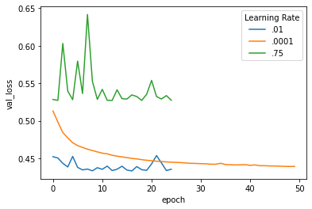

```python
sns.lineplot(x='epoch', y='val_loss', hue='Learning Rate', data=df_learning)
```

# Visualize results for learning rates (cont’d)

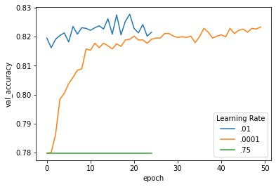

```python
sns.lineplot(x='epoch', y='val_accuracy', hue='Learning Rate', data=df_learning)
```

- We obtain the best results when the learning rate is set to 0.01 and the model seems to clearly underfit when the learning rate is high

# Knowledge check

# Module completion checklist

| Objective | Complete |
| --- | --- |
| Summarize the role that batch size and epochs play in neural network training | **✔** |
| Implement a custom neural network to demonstrate model fit with different learning rates | **✔** |

# Congratulations on completing this module!

You are now ready to try tasks 1-7 in the Exercise for this topic